# R Notebook Stadistic

Alumns: Pedro Ferreira A17029, Daniel Fernandes A17014, Enmanuel Martins A16430

Librerias a usar

```r
setwd("~/Rproject")
library(readr)
library(ROCR)
library(plotly)
#this library is to implement a generalized linear model (GLM)
library(dplyr)
library(tidyr)
#this library is to implement a logistoic regresion
library(glmnet)
library(caTools)

library(naniar)
library(tidyverse)
library(ggplot2)
library(ggcorrplot)
library(randomForest)
library(caret)
```

We define the setwd to specify where it should search for files, declaring that the project initializes in the location /Rproject.

We define the data.csv as data_cancer.

```r
data_cancer <- read.csv('./data.csv')
```

```r
# Remove the 'id' column and the 'X' column
data_cancer <- data_cancer[, -1]  # Remove 'id' column
data_cancer <- data_cancer[, -ncol(data_cancer)]  # Remove last column (assuming it's 'X')
```

```r
head(data_cancer)
```

|  | diagnosis | radius_mean | texture_mean | perimeter_mean | area_mean | smoothness_mean | compactness_mean | concavity_mean | concave.points_mean | symmetry_mean | fractal_dimension_mean | radius_se | texture_se | perimeter_se | area_se | smoothness_se | compactness_se | concavity_se | concave.points_se | symmetry_se | fractal_dimension_se | radius_worst | texture_worst | perimeter_worst | area_worst | smoothness_worst | compactness_worst | concavity_worst | concave.points_worst | … |
| --- | --- | --- | --- | --- | --- | --- | --- | --- | --- | --- | --- | --- | --- | --- | --- | --- | --- | --- | --- | --- | --- | --- | --- | --- | --- | --- | --- | --- | --- | --- |
| 1 | M | 17.99 | 10.38 | 122.80 | 1001.0 | 0.11840 | 0.27760 | 0.3001 | 0.14710 | 0.2419 | 0.07871 | 1.0950 | 0.9053 | 8.589 | 153.40 | 0.006399 | 0.04904 | 0.05373 | 0.01587 | 0.03003 | 0.006193 | 25.38 | 17.33 | 184.60 | 2019.0 | 0.1622 | 0.6656 | 0.7119 | 0.2654 | … |
| 2 | M | 20.57 | 17.77 | 132.90 | 1326.0 | 0.08474 | 0.07864 | 0.0869 | 0.07017 | 0.1812 | 0.05667 | 0.5435 | 0.7339 | 3.398 | 74.08 | 0.005225 | 0.01308 | 0.01860 | 0.01340 | 0.01389 | 0.003532 | 24.99 | 23.41 | 158.80 | 1956.0 | 0.1238 | 0.1866 | 0.2416 | 0.1860 | … |
| 3 | M | 19.69 | 21.25 | 130.00 | 1203.0 | 0.10960 | 0.15990 | 0.1974 | 0.12790 | 0.2069 | 0.05999 | 0.7456 | 0.7869 | 4.585 | 94.03 | 0.006150 | 0.04006 | 0.03832 | 0.02058 | 0.02250 | 0.004571 | 23.57 | 25.53 | 152.50 | 1709.0 | 0.1444 | 0.4245 | 0.4504 | 0.2430 | … |
| 4 | M | 11.42 | 20.38 | 77.58 | 386.1 | 0.14250 | 0.28390 | 0.2414 | 0.10520 | 0.2597 | 0.09744 | 0.4956 | 1.1560 | 3.445 | 27.23 | 0.009110 | 0.07458 | 0.05661 | 0.01867 | 0.05963 | 0.009208 | 14.91 | 26.50 | 98.87 | 567.7 | 0.2098 | 0.8663 | 0.6869 | 0.2575 | … |
| 5 | M | 20.29 | 14.34 | 135.10 | 1297.0 | 0.10030 | 0.13280 | 0.1980 | 0.10430 | 0.1809 | 0.05883 | 0.7572 | 0.7813 | 5.438 | 94.44 | 0.011490 | 0.02461 | 0.05688 | 0.01885 | 0.01756 | 0.005115 | 22.54 | 16.67 | 152.20 | 1575.0 | 0.1374 | 0.2050 | 0.4000 | 0.1625 | … |
| 6 | M | 12.45 | 15.70 | 82.57 | 477.1 | 0.12780 | 0.17000 | 0.1578 | 0.08089 | 0.2087 | 0.07613 | 0.3345 | 0.8902 | 2.217 | 27.19 | 0.007510 | 0.03345 | 0.03672 | 0.01137 | 0.02165 | 0.005082 | 15.47 | 23.75 | 103.40 | 741.6 | 0.1791 | 0.5249 | 0.5355 | 0.1741 | … |

```r
str(data_cancer)
```

```
'data.frame':   569 obs. of  31 variables:
 $ diagnosis              : chr  "M" "M" "M" "M" ...
 $ radius_mean            : num  18 20.6 19.7 11.4 20.3 ...
 $ texture_mean           : num  10.4 17.8 21.2 20.4 14.3 ...
 $ perimeter_mean         : num  122.8 132.9 130 77.6 135.1 ...
 $ area_mean              : num  1001 1326 1203 386 1297 ...
 $ smoothness_mean        : num  0.1184 0.0847 0.1096 0.1425 0.1003 ...
 $ compactness_mean       : num  0.2776 0.0786 0.1599 0.2839 0.1328 ...
 $ concavity_mean         : num  0.3001 0.0869 0.1974 0.2414 0.198 ...
 $ concave.points_mean    : num  0.1471 0.0702 0.1279 0.1052 0.1043 ...
 $ symmetry_mean          : num  0.242 0.181 0.207 0.26 0.181 ...
 $ fractal_dimension_mean : num  0.0787 0.0567 0.06 0.0974 0.0588 ...
 $ radius_se              : num  1.095 0.543 0.746 0.496 0.757 ...
 $ texture_se             : num  0.905 0.734 0.787 1.156 0.781 ...
 $ perimeter_se           : num  8.59 3.4 4.58 3.44 5.44 ...
```

[output cut: 17 more lines]

```r
summary(data_cancer)
```

```
  diagnosis          radius_mean      texture_mean   perimeter_mean     area_mean      smoothness_mean   compactness_mean  concavity_mean
 Length:569         Min.   : 6.981   Min.   : 9.71   Min.   : 43.79   Min.   : 143.5   Min.   :0.05263   Min.   :0.01938   Min.   :0.00000
 Class :character   1st Qu.:11.700   1st Qu.:16.17   1st Qu.: 75.17   1st Qu.: 420.3   1st Qu.:0.08637   1st Qu.:0.06492   1st Qu.:0.02956
 Mode  :character   Median :13.370   Median :18.84   Median : 86.24   Median : 551.1   Median :0.09587   Median :0.09263   Median :0.06154
                    Mean   :14.127   Mean   :19.29   Mean   : 91.97   Mean   : 654.9   Mean   :0.09636   Mean   :0.10434   Mean   :0.08880
                    3rd Qu.:15.780   3rd Qu.:21.80   3rd Qu.:104.10   3rd Qu.: 782.7   3rd Qu.:0.10530   3rd Qu.:0.13040   3rd Qu.:0.13070
                    Max.   :28.110   Max.   :39.28   Max.   :188.50   Max.   :2501.0   Max.   :0.16340   Max.   :0.34540   Max.   :0.42680
 concave.points_mean symmetry_mean    fractal_dimension_mean   radius_se        texture_se      perimeter_se       area_se
 Min.   :0.00000     Min.   :0.1060   Min.   :0.04996        Min.   :0.1115   Min.   :0.3602   Min.   : 0.757   Min.   :  6.802
 1st Qu.:0.02031     1st Qu.:0.1619   1st Qu.:0.05770        1st Qu.:0.2324   1st Qu.:0.8339   1st Qu.: 1.606   1st Qu.: 17.850
 Median :0.03350     Median :0.1792   Median :0.06154        Median :0.3242   Median :1.1080   Median : 2.287   Median : 24.530
 Mean   :0.04892     Mean   :0.1812   Mean   :0.06280        Mean   :0.4052   Mean   :1.2169   Mean   : 2.866   Mean   : 40.337
 3rd Qu.:0.07400     3rd Qu.:0.1957   3rd Qu.:0.06612        3rd Qu.:0.4789   3rd Qu.:1.4740   3rd Qu.: 3.357   3rd Qu.: 45.190
 Max.   :0.20120     Max.   :0.3040   Max.   :0.09744        Max.   :2.8730   Max.   :4.8850   Max.   :21.980   Max.   :542.200
 smoothness_se      compactness_se      concavity_se     concave.points_se   symmetry_se       fractal_dimension_se  radius_worst
 Min.   :0.001713   Min.   :0.002252   Min.   :0.00000   Min.   :0.000000   Min.   :0.007882   Min.   :0.0008948    Min.   : 7.93
 1st Qu.:0.005169   1st Qu.:0.013080   1st Qu.:0.01509   1st Qu.:0.007638   1st Qu.:0.015160   1st Qu.:0.0022480    1st Qu.:13.01
 Median :0.006380   Median :0.020450   Median :0.02589   Median :0.010930   Median :0.018730   Median :0.0031870    Median :14.97
 Mean   :0.007041   Mean   :0.025478   Mean   :0.03189   Mean   :0.011796   Mean   :0.020542   Mean   :0.0037949    Mean   :16.27
 3rd Qu.:0.008146   3rd Qu.:0.032450   3rd Qu.:0.04205   3rd Qu.:0.014710   3rd Qu.:0.023480   3rd Qu.:0.0045580    3rd Qu.:18.79
 Max.   :0.031130   Max.   :0.135400   Max.   :0.39600   Max.   :0.052790   Max.   :0.078950   Max.   :0.0298400    Max.   :36.04
 texture_worst   perimeter_worst    area_worst     smoothness_worst  compactness_worst concavity_worst  concave.points_worst symmetry_worst
 Min.   :12.02   Min.   : 50.41   Min.   : 185.2   Min.   :0.07117   Min.   :0.02729   Min.   :0.0000   Min.   :0.00000      Min.   :0.1565
 1st Qu.:21.08   1st Qu.: 84.11   1st Qu.: 515.3   1st Qu.:0.11660   1st Qu.:0.14720   1st Qu.:0.1145   1st Qu.:0.06493      1st Qu.:0.2504
 Median :25.41   Median : 97.66   Median : 686.5   Median :0.13130   Median :0.21190   Median :0.2267   Median :0.09993      Median :0.2822
 Mean   :25.68   Mean   :107.26   Mean   : 880.6   Mean   :0.13237   Mean   :0.25427   Mean   :0.2722   Mean   :0.11461      Mean   :0.2901
 3rd Qu.:29.72   3rd Qu.:125.40   3rd Qu.:1084.0   3rd Qu.:0.14600   3rd Qu.:0.33910   3rd Qu.:0.3829   3rd Qu.:0.16140      3rd Qu.:0.3179
 Max.   :49.54   Max.   :251.20   Max.   :4254.0   Max.   :0.22260   Max.   :1.05800   Max.   :1.2520   Max.   :0.29100      Max.   :0.6638
 fractal_dimension_worst
 Min.   :0.05504
 1st Qu.:0.07146
 Median :0.08004
 Mean   :0.08395
 3rd Qu.:0.09208
 Max.   :0.20750
```

```r
data_cancerGML <- data_cancer
```

```r
# Convert the 'diagnosis' variable to a binary factor
data_cancer$diagnosis <- as.factor(data_cancer$diagnosis)
```

```r
# Check the structure of the data after preprocessing
str(data_cancer)
```

```
'data.frame':   569 obs. of  31 variables:
 $ diagnosis              : Factor w/ 2 levels "B","M": 2 2 2 2 2 2 2 2 2 2 ...
 $ radius_mean            : num  18 20.6 19.7 11.4 20.3 ...
 $ texture_mean           : num  10.4 17.8 21.2 20.4 14.3 ...
 $ perimeter_mean         : num  122.8 132.9 130 77.6 135.1 ...
 $ area_mean              : num  1001 1326 1203 386 1297 ...
 $ smoothness_mean        : num  0.1184 0.0847 0.1096 0.1425 0.1003 ...
 $ compactness_mean       : num  0.2776 0.0786 0.1599 0.2839 0.1328 ...
 $ concavity_mean         : num  0.3001 0.0869 0.1974 0.2414 0.198 ...
 $ concave.points_mean    : num  0.1471 0.0702 0.1279 0.1052 0.1043 ...
 $ symmetry_mean          : num  0.242 0.181 0.207 0.26 0.181 ...
 $ fractal_dimension_mean : num  0.0787 0.0567 0.06 0.0974 0.0588 ...
 $ radius_se              : num  1.095 0.543 0.746 0.496 0.757 ...
 $ texture_se             : num  0.905 0.734 0.787 1.156 0.781 ...
 $ perimeter_se           : num  8.59 3.4 4.58 3.44 5.44 ...
```

[output cut: 17 more lines]

```r
data_1 <- data_cancer %>%
  as.data.frame() %>%
  select_if(is.numeric) %>%
  gather(key = "variable", value = "value")
```

The first block of code transforms the dataset `data_cancer` into a dataframe format, selects the numerical variables using `select_if(is.numeric)`, and then reorganizes the data into a long format using `gather(key = "variable", value = "value")`, where each row represents a unique observation of a variable and its corresponding value.

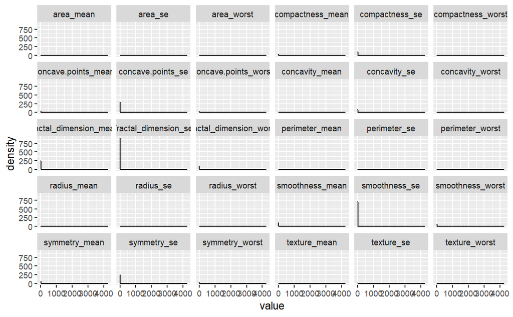

```r
ggplot(data_1, aes(value)) +
  geom_density() +
  facet_wrap(~variable)
```

```r
data_cancer$diagnosis <- factor(data_cancer$diagnosis, levels = c("M","B"), labels = c(0,1))
```

The first block of code converts the variable `diagnosis` of the dataset `data_cancer` into a factor with levels “M” and “B”, and labels “0” and “1” respectively. This is done using the `factor()` function with the arguments `levels` and `labels` to specify the levels and corresponding labels.

```r
data_cancer$diagnosis <- as.character(data_cancer$diagnosis)

data_cancer$diagnosis <- as.numeric(data_cancer$diagnosis)
```

```r
str(data_cancer)
```

```
'data.frame':   569 obs. of  31 variables:
 $ diagnosis              : num  0 0 0 0 0 0 0 0 0 0 ...
 $ radius_mean            : num  18 20.6 19.7 11.4 20.3 ...
 $ texture_mean           : num  10.4 17.8 21.2 20.4 14.3 ...
 $ perimeter_mean         : num  122.8 132.9 130 77.6 135.1 ...
 $ area_mean              : num  1001 1326 1203 386 1297 ...
 $ smoothness_mean        : num  0.1184 0.0847 0.1096 0.1425 0.1003 ...
 $ compactness_mean       : num  0.2776 0.0786 0.1599 0.2839 0.1328 ...
 $ concavity_mean         : num  0.3001 0.0869 0.1974 0.2414 0.198 ...
 $ concave.points_mean    : num  0.1471 0.0702 0.1279 0.1052 0.1043 ...
 $ symmetry_mean          : num  0.242 0.181 0.207 0.26 0.181 ...
 $ fractal_dimension_mean : num  0.0787 0.0567 0.06 0.0974 0.0588 ...
 $ radius_se              : num  1.095 0.543 0.746 0.496 0.757 ...
 $ texture_se             : num  0.905 0.734 0.787 1.156 0.781 ...
 $ perimeter_se           : num  8.59 3.4 4.58 3.44 5.44 ...
```

[output cut: 17 more lines]

```r
data_cancer <- data_cancer %>% relocate(diagnosis,.after= fractal_dimension_worst)
```

The code `data_cancer <- data_cancer %>% relocate(diagnosis, .after = fractal_dimension_worst)` relocates the column “diagnosis” in the dataframe `data_cancer` just after the column “fractal_dimension_worst”. This means that the “diagnosis” column will be moved to the position immediately after the “fractal_dimension_worst” column in the dataframe. This operation helps organize the columns of the dataframe in a more readable or logical manner.

```r
r <- cor(data_cancer[,0:31])

round(r,2)
```

```
                        radius_mean texture_mean perimeter_mean area_mean smoothness_mean compactness_mean concavity_mean concave.points_mean
radius_mean                    1.00         0.32           1.00      0.99            0.17             0.51           0.68                0.82
texture_mean                   0.32         1.00           0.33      0.32           -0.02             0.24           0.30                0.29
perimeter_mean                 1.00         0.33           1.00      0.99            0.21             0.56           0.72                0.85
area_mean                      0.99         0.32           0.99      1.00            0.18             0.50           0.69                0.82
smoothness_mean                0.17        -0.02           0.21      0.18            1.00             0.66           0.52                0.55
compactness_mean               0.51         0.24           0.56      0.50            0.66             1.00           0.88                0.83
concavity_mean                 0.68         0.30           0.72      0.69            0.52             0.88           1.00                0.92
concave.points_mean            0.82         0.29           0.85      0.82            0.55             0.83           0.92                1.00
symmetry_mean                  0.15         0.07           0.18      0.15            0.56             0.60           0.50                0.46
fractal_dimension_mean        -0.31        -0.08          -0.26     -0.28            0.58             0.57           0.34                0.17
radius_se                      0.68         0.28           0.69      0.73            0.30             0.50           0.63                0.70
texture_se                    -0.10         0.39          -0.09     -0.07            0.07             0.05           0.08                0.02
perimeter_se                   0.67         0.28           0.69      0.73            0.30             0.55           0.66                0.71
area_se                        0.74         0.26           0.74      0.80            0.25             0.46           0.62                0.69
smoothness_se                 -0.22         0.01          -0.20     -0.17            0.33             0.14           0.10                0.03
compactness_se                 0.21         0.19           0.25      0.21            0.32             0.74           0.67                0.49
concavity_se                   0.19         0.14           0.23      0.21            0.25             0.57           0.69                0.44
concave.points_se              0.38         0.16           0.41      0.37            0.38             0.64           0.68                0.62
symmetry_se                   -0.10         0.01          -0.08     -0.07            0.20             0.23           0.18                0.10
fractal_dimension_se          -0.04         0.05          -0.01     -0.02            0.28             0.51           0.45                0.26
radius_worst                   0.97         0.35           0.97      0.96            0.21             0.54           0.69                0.83
texture_worst                  0.30         0.91           0.30      0.29            0.04             0.25           0.30                0.29
perimeter_worst                0.97         0.36           0.97      0.96            0.24             0.59           0.73                0.86
area_worst                     0.94         0.34           0.94      0.96            0.21             0.51           0.68                0.81
smoothness_worst               0.12         0.08           0.15      0.12            0.81             0.57           0.45                0.45
compactness_worst              0.41         0.28           0.46      0.39            0.47             0.87           0.75                0.67
concavity_worst                0.53         0.30           0.56      0.51            0.43             0.82           0.88                0.75
concave.points_worst           0.74         0.30           0.77      0.72            0.50             0.82           0.86                0.91
symmetry_worst                 0.16         0.11           0.19      0.14            0.39             0.51           0.41                0.38
fractal_dimension_worst        0.01         0.12           0.05      0.00            0.50             0.69           0.51                0.37
diagnosis                     -0.73        -0.42          -0.74     -0.71           -0.36            -0.60          -0.70               -0.78
                        symmetry_mean fractal_dimension_mean radius_se texture_se perimeter_se area_se smoothness_se compactness_se
radius_mean                      0.15                  -0.31      0.68      -0.10         0.67    0.74         -0.22           0.21
texture_mean                     0.07                  -0.08      0.28       0.39         0.28    0.26          0.01           0.19
perimeter_mean                   0.18                  -0.26      0.69      -0.09         0.69    0.74         -0.20           0.25
area_mean                        0.15                  -0.28      0.73      -0.07         0.73    0.80         -0.17           0.21
smoothness_mean                  0.56                   0.58      0.30       0.07         0.30    0.25          0.33           0.32
compactness_mean                 0.60                   0.57      0.50       0.05         0.55    0.46          0.14           0.74
concavity_mean                   0.50                   0.34      0.63       0.08         0.66    0.62          0.10           0.67
```

[output cut: 105 more lines]

```
concavity_se                -0.25
concave.points_se           -0.41
symmetry_se                  0.01
fractal_dimension_se        -0.08
radius_worst                -0.78
texture_worst               -0.46
perimeter_worst             -0.78
area_worst                  -0.73
smoothness_worst            -0.42
compactness_worst           -0.59
concavity_worst             -0.66
concave.points_worst        -0.79
symmetry_worst              -0.42
fractal_dimension_worst     -0.32
diagnosis                    1.00
```

The following R code snippet calculates the correlation matrix among the numerical variables of the dataset `data_cancer`. The correlation matrix is a statistical tool that displays the relationship between pairs of variables.

The `cor()` function is used to compute the correlations between the variables, and `round()` is used to round the correlation values to two decimal places.

The result is a matrix where each cell contains the correlation coefficient between two variables. Values close to 1 indicate a strong positive correlation, values close to -1 indicate a strong negative correlation, and values close to 0 indicate a weak or null correlation.

For example, a positive correlation between two variables means that when one variable increases, the other also tends to increase, while a negative correlation indicates that when one variable increases, the other tends to decrease.

The result provides information about the relationship between different features of the dataset, which can aid in data analysis and interpretation.

Below is an excerpt of the correlation matrix rounded to two decimal places:

|  | texture_mean | perimeter_mean | area_mean | smoothness_mean | … |
| --- | --- | --- | --- | --- | --- |
| texture_mean | 1.00 | 0.33 | 0.32 | -0.02 | … |
| perimeter_mean | 0.33 | 1.00 | 0.99 | 0.21 | … |
| area_mean | 0.32 | 0.99 | 1.00 | 0.18 | … |
| smoothness_mean | -0.02 | 0.21 | 0.18 | 1.00 | … |
| compactness_mean | 0.24 | 0.56 | 0.50 | 0.66 | … |
| concavity_mean | 0.30 | 0.72 | 0.69 | 0.52 | … |
| concave.points_mean | 0.29 | 0.85 | 0.82 | 0.55 | … |
| symmetry_mean | 0.07 | 0.18 | 0.15 | 0.56 | … |
| fractal_dimension_mean | -0.08 | -0.26 | -0.28 | 0.58 | … |
| radius_se | 0.28 | 0.69 | 0.73 | 0.30 | … |
| … | … | … | … | … | … |

This kind of analysis is commonly used in descriptive statistics and in the initial exploration of data to better understand the relationships between variables and how they may influence the problem at hand.

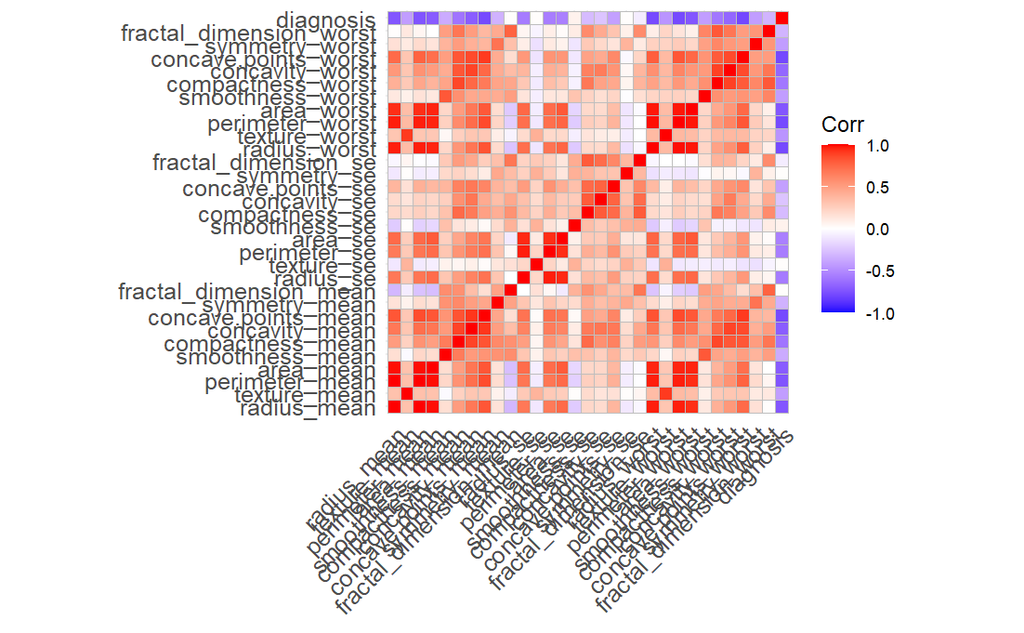

```r
ggcorrplot(r)
```

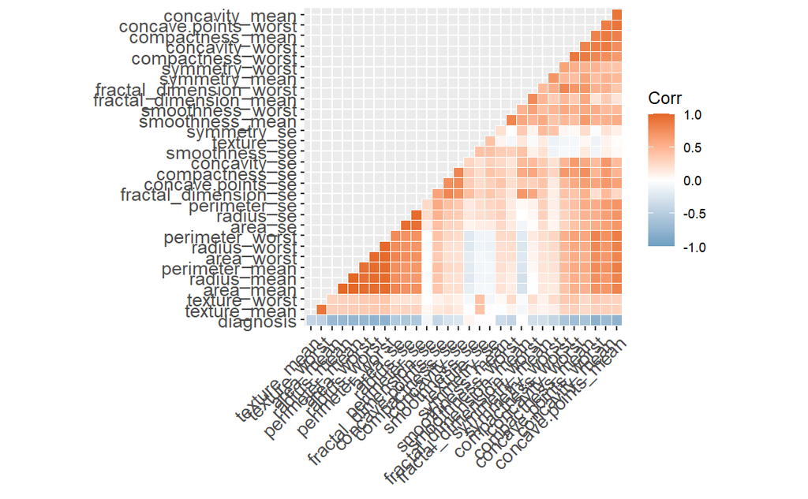

```r
ggcorrplot(r, hc.order = TRUE, type = "lower",
           outline.col = "white",
           ggtheme = ggplot2::theme_gray,
           colors = c("#6D9EC1", "white", "#E46726"))
```

```r
data_cancer <- data_cancer[,0:31]
```

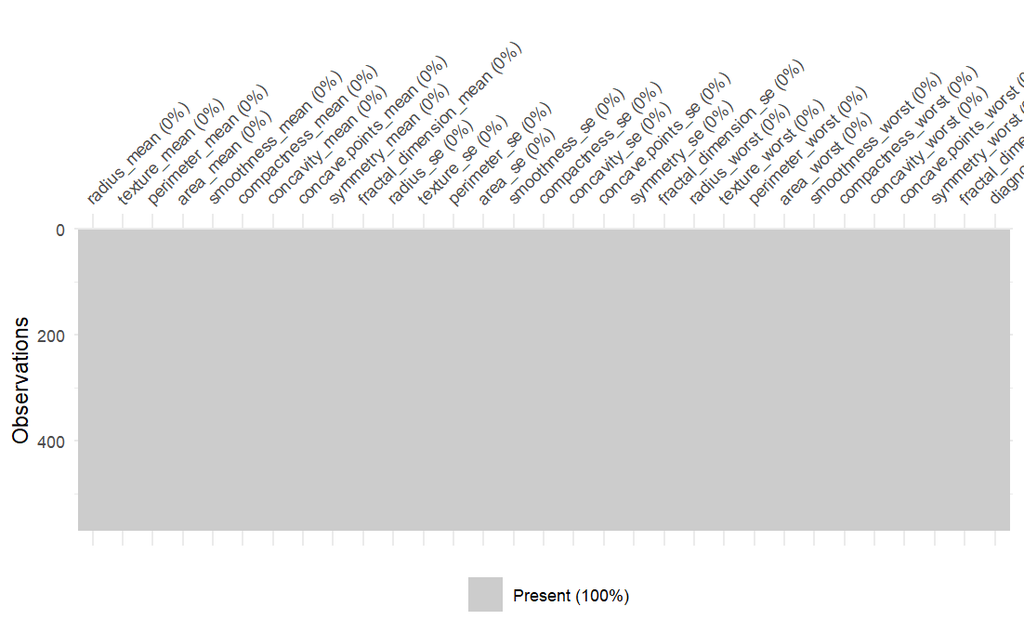

```r
vis_miss(data_cancer)
```

```r
sum(is.na(data_cancer))
```

```
[1] 0
```

We verify that there are no null values within this `data_cancer` dataset.

```r
sapply(data_cancer,function(x)sum(is.na(x)))
```

```
            radius_mean            texture_mean          perimeter_mean               area_mean         smoothness_mean
                      0                       0                       0                       0                       0
       compactness_mean          concavity_mean     concave.points_mean           symmetry_mean  fractal_dimension_mean
                      0                       0                       0                       0                       0
              radius_se              texture_se            perimeter_se                 area_se           smoothness_se
                      0                       0                       0                       0                       0
         compactness_se            concavity_se       concave.points_se             symmetry_se    fractal_dimension_se
                      0                       0                       0                       0                       0
           radius_worst           texture_worst         perimeter_worst              area_worst        smoothness_worst
                      0                       0                       0                       0                       0
      compactness_worst         concavity_worst    concave.points_worst          symmetry_worst fractal_dimension_worst
                      0                       0                       0                       0                       0
              diagnosis
                      0
```

```r
# Dividir los datos en conjuntos de entrenamiento y prueba (70% entrenamiento, 30% prueba)
set.seed(123)  # Para reproducibilidad
indices <- sample(1:nrow(data_cancer), size = floor(0.7 * nrow(data_cancer)))
train_set <- data_cancer[indices, ]
test_set <- data_cancer[-indices, ]
```

This code divides the `data_cancer` dataset into training and testing sets using a random partitioning approach. Firstly, a random seed is set to ensure the reproducibility of results. Then, random indices representing 70% of the rows of the original dataset are generated, which are used to select the corresponding rows from the original dataset as the training set (`train_set`). The remaining rows form the testing set (`test_set`).

```r
# Entrenar el modelo de regresión logística
model <- glm(diagnosis ~ ., data = train_set, family = binomial, maxit = 100)
```

This code trains a logistic regression model using the `glm()` function in R. The goal is to predict the variable `diagnosis` (which appears to be a binary variable) based on all other variables in the training dataset (`train_set`). The argument `family = binomial` is specified to indicate that it is a binary logistic regression model. The `maxit` parameter sets the maximum number of iterations allowed during the optimization process.

```r
summary(model)
```

```
Call:
glm(formula = diagnosis ~ ., family = binomial, data = train_set,
    maxit = 100)

Coefficients:
                          Estimate Std. Error z value Pr(>|z|)
(Intercept)              8.971e+03  2.517e+07       0        1
radius_mean              3.372e+03  8.559e+06       0        1
texture_mean            -3.899e+01  2.660e+05       0        1
perimeter_mean          -4.531e+02  1.294e+06       0        1
area_mean               -3.176e+00  3.659e+04       0        1
smoothness_mean         -2.110e+04  6.185e+07       0        1
compactness_mean         2.520e+04  5.452e+07       0        1
concavity_mean          -4.850e+03  4.910e+07       0        1
concave.points_mean      5.367e+03  5.982e+07       0        1
symmetry_mean            5.404e+03  1.919e+07       0        1
fractal_dimension_mean  -4.804e+04  1.300e+08       0        1
radius_se               -3.112e+03  2.109e+07       0        1
texture_se              -2.979e+02  1.814e+06       0        1
perimeter_se             2.064e+02  2.127e+06       0        1
area_se                  6.312e+00  1.120e+05       0        1
smoothness_se           -1.966e+04  2.063e+08       0        1
compactness_se          -3.828e+04  8.933e+07       0        1
concavity_se             1.484e+04  3.585e+07       0        1
concave.points_se       -4.446e+04  1.751e+08       0        1
symmetry_se              1.495e+04  6.502e+07       0        1
fractal_dimension_se     3.255e+05  6.964e+08       0        1
radius_worst            -9.085e+02  3.493e+06       0        1
texture_worst            5.536e+00  2.695e+05       0        1
perimeter_worst          3.905e+01  3.805e+05       0        1
area_worst               3.727e+00  2.356e+04       0        1
smoothness_worst         3.449e+03  3.660e+07       0        1
compactness_worst        2.447e+03  1.231e+07       0        1
concavity_worst         -1.591e+03  1.411e+07       0        1
concave.points_worst    -8.924e+03  3.162e+07       0        1
symmetry_worst          -4.872e+03  1.546e+07       0        1
fractal_dimension_worst -1.266e+04  6.626e+07       0        1

(Dispersion parameter for binomial family taken to be 1)

    Null deviance: 5.1500e+02  on 397  degrees of freedom
Residual deviance: 4.5672e-10  on 367  degrees of freedom
AIC: 62

Number of Fisher Scoring iterations: 36
```

```r
# Hacer predicciones en el conjunto de prueba
predictions <- predict(model, newdata = test_set, type = "response")
```

This code makes predictions on the test set using the previously trained logistic regression model. The `predict()` function is used specifying the trained model (`model`) and the new test data (`test_set`). The argument `type = "response"` indicates that we want to obtain the probabilities of belonging to the positive class.

```r
# Convertir las probabilidades predichas en clases (Maligno o Benigno)
predicted_classes <- ifelse(predictions > 0.5, "M", "B")
```

```r
# Evaluar el rendimiento del modelo
confusion_matrix <- table(predicted_classes, test_set$diagnosis)
print(confusion_matrix)
```

```
predicted_classes  0  1
                B 71  5
                M  2 93
```

This code generates a confusion matrix to evaluate the performance of the classification model. The confusion matrix shows the model’s predictions compared to the actual labels in the test set.

- The values on the main diagonal represent correct predictions.
- The values off the main diagonal represent prediction errors.

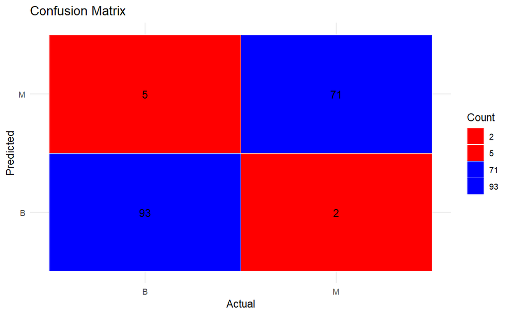

```r
# Crear la matriz de confusión como un marco de datos
confusion_df <- data.frame(
  Actual = rep(c("M", "B"), each = 2),
  Predicted = c("M", "B", "M", "B"),
  Count = c(confusion_matrix[1, 1], confusion_matrix[2, 1],
            confusion_matrix[1, 2], confusion_matrix[2, 2])
)

# Graficar la matriz de confusión
ggplot(confusion_df, aes(x = Actual, y = Predicted, fill = factor(Count))) +
  geom_tile(color = "white") +
  geom_text(aes(label = Count)) +
  scale_fill_manual(values = c("#FF0000", "#FF0000", "#0000FF", "#0000FF"),
                    name = "Count") +
  theme_minimal() +
  labs(x = "Actual", y = "Predicted", title = "Confusion Matrix")
```

This code creates a visualization of the confusion matrix using ggplot2 in R. The confusion matrix is a useful tool for evaluating the performance of a classification model by showing how often the model’s predictions match or differ from the actual classes.